# Deltas Notebook 2

Let’s import at all of the packages and the data (RS and Geographic):

```r
library(tidyverse)
library(gridExtra)
```

```r
library(maps)
library(ggthemes)
library(ggforce)
DeltasClean <- read_csv("../data/out/deltas_clean_v2.csv")
DeltaLocations <- read_csv("../data/DeltaLocations.csv")
```

As a reminder, for each of the 47 deltas there are measurements of Land & Water areas at Upstream, Downstream and ‘Middle’ locations on the delta. We first lump all the observations together, and look to see which Deltas have many observations:

```r
#counts per delta
count(DeltasClean, Delta)
```

| Delta | n |
| --- | --- |
| Amazon | 300 |
| Amur | 788 |
| Brahmani | 1115 |
| Burdekin | 1572 |
| Choa | 1133 |
| Colorado | 1370 |
| Congo | 225 |
| Danube | 1262 |
| Dnieper | 1473 |
| Ebro | 1515 |

[output cut: 37 more lines]

Now, by each month.. where the colorbar represents the number of observations (n) for each month for a given delta:

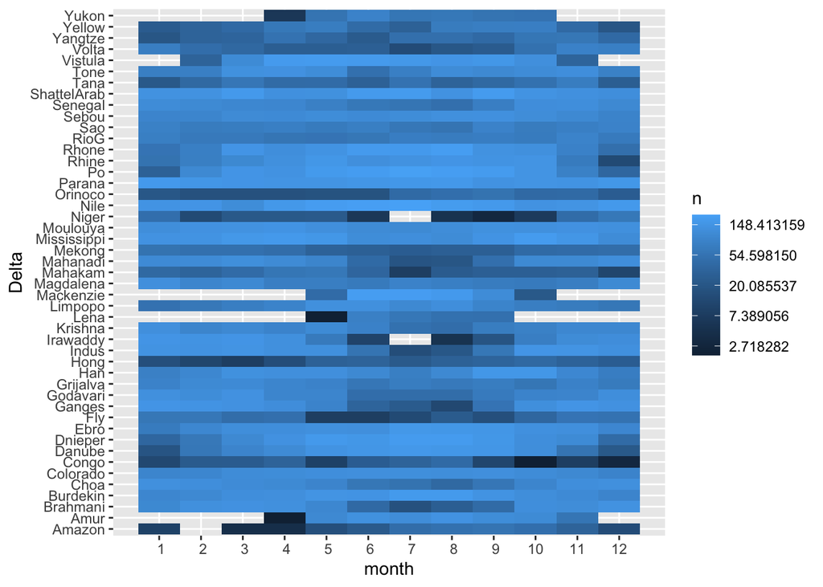

```r
ggplot(count(DeltasClean, Delta, month),
       aes(y = Delta, x = month, fill=n)) +
  geom_tile() +
  scale_x_discrete(limits = c(1:12), breaks = c(1:12)) +
  expand_limits(x = c(1,12)) +
  scale_fill_gradient( trans = 'log' )
```

In the above heat map, dark colors (and no color) represent data paucity (and data gaps). Deltas with light colors (e.g., the Parana, Nile, Ebro, Colorado, Brahmani) have lots of data, spread out through the months of the year.

I’ll remove/subset the deltas with sparse coverage (specifically, months with no coverage)….

```r
# need 10 data points per month for NDSSI and NDVI
EnoughObsPerMonth <- DeltasClean %>% ungroup() %>%
  count(Delta, month, surface) %>%
  group_by(surface) %>%
  filter( n >= 5)

#find deltas missing a given month of observations
DeltaMonthCounts <- EnoughObsPerMonth %>%
  ungroup() %>%
  count(Delta)

# need 12 months of water and land obs, so 24 mo total
EnoughMonths <- DeltaMonthCounts %>%
 filter( n == 24)

CompleteObsDeltas <- pull(EnoughMonths, Delta)

#remove them
DeltasCleaner <- DeltasClean %>%
  filter(Delta %in% CompleteObsDeltas)

#add the real dates in month date format
DeltasCleaner$date <- as.Date(paste(DeltasCleaner$year, DeltasCleaner$month, "01", sep="-"), "%Y-%m-%d")

#remove intermediate data
rm(CompleteObsDeltas, EnoughMonths, EnoughObsPerMonth, DeltaMonthCounts, DeltasClean)
```

Ok, now let’s organize this raw data into 1 dataframe, with delta, max and min NDVI (and month), max and min NDSSI(and month), NDVI and NDSSI range.

```r
#take the mean NDVI and NDSSI for each month, for each delta
DeltaMeans <- DeltasCleaner %>%
  group_by(Delta, month, surface) %>%
  summarize(MeanNDVI = mean(ndvi, na.rm = TRUE), MeanNDSSI = mean(ndssi, na.rm = TRUE))

#####

DeltaMaxNDVI <-
  DeltaMeans %>%
  filter(surface == 'Land')  %>%
  select (-c(MeanNDSSI)) %>%
  group_by(Delta) %>%
  slice(which.max(MeanNDVI)) %>%
  rename(MaxMeanNDVImonth = month, MaxMeanNDVI = MeanNDVI)

DeltaMaxNDSSI <-
  DeltaMeans %>%
  filter(surface == 'Water')  %>%
  select (-c(MeanNDVI)) %>%
  group_by(Delta) %>%
  slice(which.max(MeanNDSSI)) %>%
  rename(MaxMeanNDSSImonth = month, MaxMeanNDSSI = MeanNDSSI)

DeltaMinNDVI <-
  DeltaMeans %>%
  filter(surface == 'Land')  %>%
  select (-c(MeanNDSSI)) %>%
  group_by(Delta) %>%
  slice(which.min(MeanNDVI)) %>%
  rename(MinMeanNDVImonth = month, MinMeanNDVI = MeanNDVI)

DeltaMinNDSSI <-
  DeltaMeans %>%
  filter(surface == 'Water')  %>%
  select (-c(MeanNDVI)) %>%
  group_by(Delta) %>%
  slice(which.min(MeanNDSSI)) %>%
  rename(MinMeanNDSSImonth = month, MinMeanNDSSI = MeanNDSSI)


#join into 1 dataframe
DeltaMaxMin <- left_join(DeltaMaxNDVI, DeltaMaxNDSSI, by = 'Delta') %>%
  left_join(.,DeltaMinNDVI, by = 'Delta') %>%
  left_join(.,DeltaMinNDSSI, by = 'Delta')

#remove intermediate data
rm(DeltaMaxNDVI, DeltaMaxNDSSI, DeltaMinNDSSI,DeltaMinNDVI)

DeltaMaxMin <- DeltaMaxMin %>%
  select(-surface.x, -surface.x.x, -surface.y, -surface.y.y)
```

And now we calculate phase shifts between NDVI and NDSSI for each delta

```r
#compare offset
DeltaMaxMin <- mutate(DeltaMaxMin,
                      MinOffset = if_else(MinMeanNDVImonth > MinMeanNDSSImonth,
                                          MinMeanNDVImonth - MinMeanNDSSImonth,
                                          MinMeanNDSSImonth - MinMeanNDVImonth),
                      MaxOffset = if_else(MaxMeanNDVImonth > MaxMeanNDSSImonth,
                                          MaxMeanNDVImonth - MaxMeanNDSSImonth,
                                          MaxMeanNDSSImonth - MaxMeanNDVImonth),
                      OffsetDiff = abs(MaxOffset - MinOffset),
                      rangeNDVI = (MaxMeanNDVI - MinMeanNDVI),
                      rangeNDSSI = (MaxMeanNDSSI - MinMeanNDSSI)
                      )

DeltaMaxMin <- DeltaMaxMin %>%
  mutate(MinOffset = ifelse(MinOffset > 6, (-1*MinOffset)+12 ,MinOffset))

DeltaMaxMin <- DeltaMaxMin %>%
  mutate(MaxOffset = ifelse(MaxOffset > 6, (-1*MaxOffset)+12 ,MaxOffset))



DeltaMaxMin
```

| Delta | MaxMeanNDVImonth | MaxMeanNDVI | MaxMeanNDSSImonth | MaxMeanNDSSI | MinMeanNDVImonth | MinMeanNDVI | MinMeanNDSSImonth | MinMeanNDSSI | MinOffset | MaxOffset | OffsetDiff | rangeNDVI | rangeNDSSI |
| --- | --- | --- | --- | --- | --- | --- | --- | --- | --- | --- | --- | --- | --- |
| Brahmani | 8 | 0.66498168 | 12 | 0.13712630 | 5 | 0.44254329 | 7 | -0.118404762 | 2 | 4 | 2 | 0.22243839 | 0.2555311 |
| Burdekin | 2 | 0.52698904 | 8 | 0.34078551 | 10 | 0.39782098 | 2 | -0.051982562 | 4 | 6 | 2 | 0.12916806 | 0.3927681 |
| Choa | 7 | 0.71788809 | 1 | 0.19557709 | 3 | 0.61108484 | 8 | -0.003734228 | 5 | 6 | 1 | 0.10680325 | 0.1993113 |
| Colorado | 2 | 0.07384282 | 5 | -0.03370475 | 8 | 0.05887065 | 2 | -0.158603868 | 6 | 3 | 3 | 0.01497217 | 0.1248991 |
| Dnieper | 7 | 0.73059539 | 12 | 0.34370273 | 2 | 0.22035925 | 6 | -0.056911658 | 4 | 5 | 1 | 0.51023614 | 0.4006144 |
| Ebro | 7 | 0.51355457 | 12 | 0.44799145 | 3 | 0.34012635 | 8 | 0.094722984 | 5 | 5 | 0 | 0.17342822 | 0.3532685 |
| Godavari | 2 | 0.51606963 | 12 | 0.22557364 | 6 | 0.34925481 | 8 | -0.228230778 | 2 | 2 | 8 | 0.16681482 | 0.4538044 |
| Grijalva | 11 | 0.74909897 | 2 | 0.18572031 | 4 | 0.61157948 | 7 | -0.011156769 | 3 | 3 | 6 | 0.13751949 | 0.1968771 |
| Han | 6 | 0.36246280 | 12 | 0.25130236 | 3 | 0.08433893 | 4 | 0.127554891 | 1 | 6 | 5 | 0.27812387 | 0.1237475 |
| Indus | 9 | 0.24411538 | 12 | 0.39130249 | 7 | 0.14702230 | 8 | -0.092697261 | 1 | 3 | 2 | 0.09709308 | 0.4839998 |

[output cut: 21 more lines]

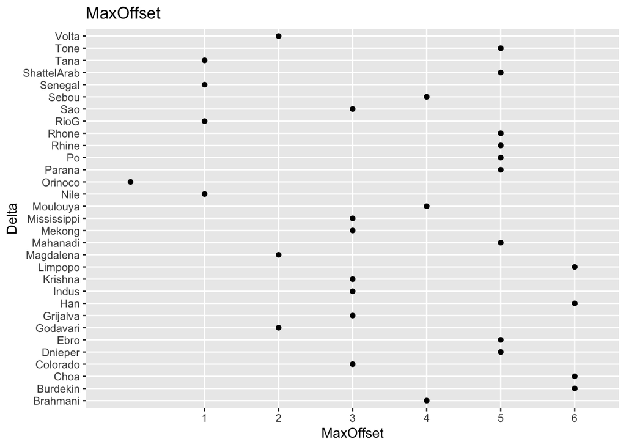

```r
ggplot(DeltaMaxMin, aes(y = Delta, x = MaxOffset)) + geom_point() +
  scale_x_discrete(limits = c(1:6), breaks = c(1:6)) +
  expand_limits(x = c(0,6))  +
  ggtitle("MaxOffset")
```

```r
# ggplot(DeltaMaxMin, aes(y = Delta, x = MinOffset)) + geom_point() +
#   scale_x_discrete(limits = c(1:6), breaks = c(1:6)) +
#   expand_limits(x = c(0,6))  +
#   ggtitle("MinOffset")
#
# ggplot(DeltaMaxMin, aes(y = Delta, x = OffsetDiff)) + geom_point() +
#   scale_x_discrete(limits = c(1:6), breaks = c(1:6)) +
#   expand_limits(x = c(0,6))  +
#   ggtitle("Offset Difference")
```

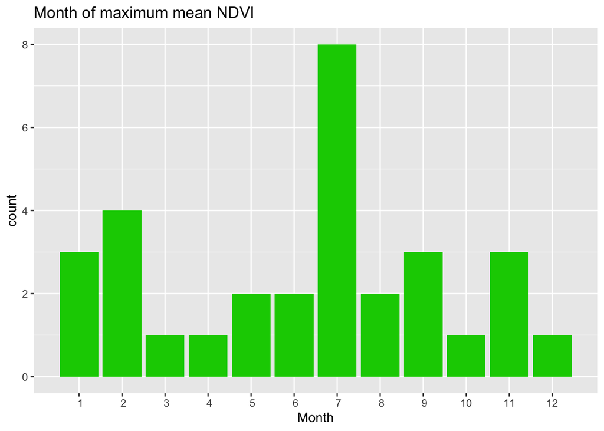

```r
ggplot(DeltaMaxMin, aes(x = MaxMeanNDVImonth)) +
  geom_bar(fill=3) +
  scale_x_discrete(limits = c(1:12), breaks = c(1:12)) +
  labs(x = "Month") +
  ggtitle("Month of maximum mean NDVI")
```

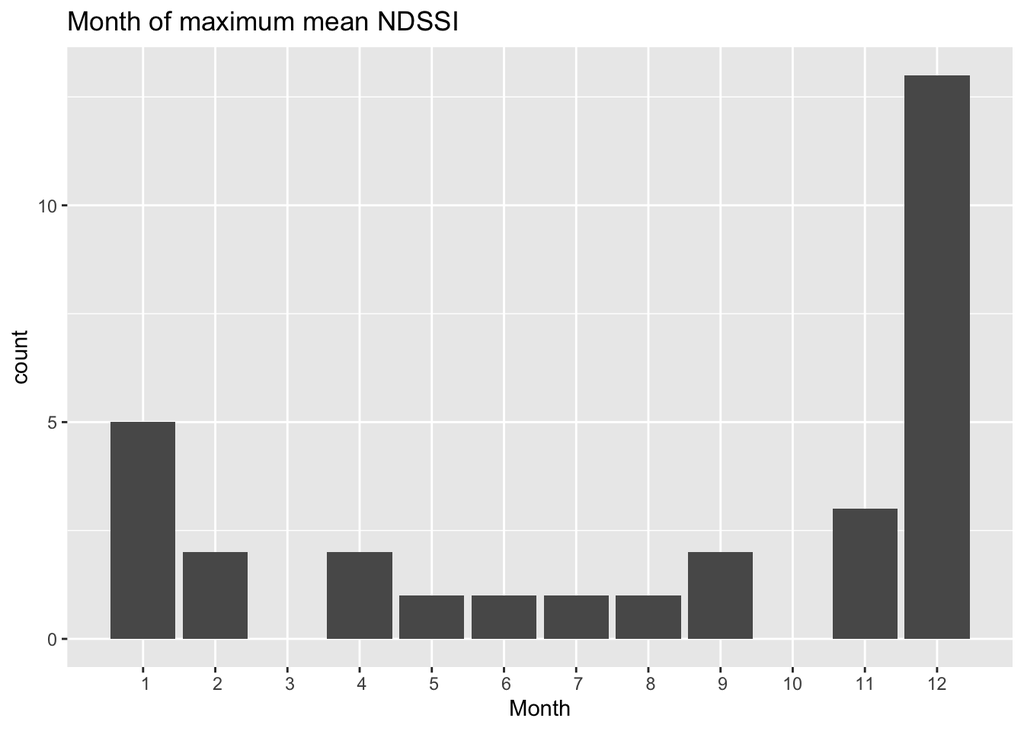

```r
ggplot(DeltaMaxMin, aes(x = MaxMeanNDSSImonth)) +
  geom_bar() +
  scale_x_discrete(limits = c(1:12), breaks = c(1:12)) +
  labs(x = "Month") +
  ggtitle("Month of maximum mean NDSSI")
```

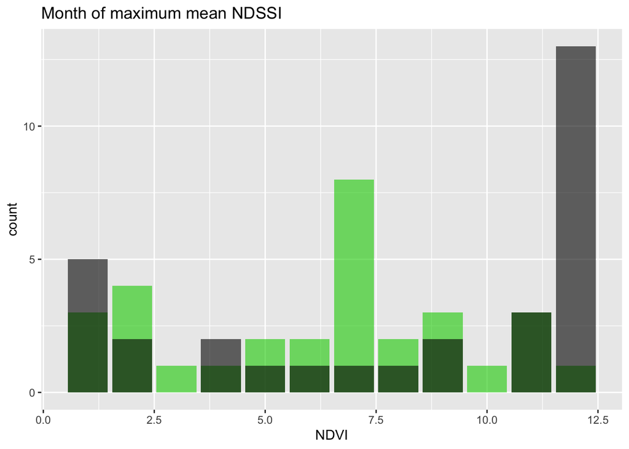

```r
ggplot(data= DeltaMaxMin) +
  geom_bar(aes(x=MaxMeanNDVImonth),fill=3, alpha = 0.6) +
  geom_bar(aes(x=MaxMeanNDSSImonth),fill=1, alpha = 0.6) +
  labs(x = "NDVI") +
  ggtitle("Month of maximum mean NDSSI")
```

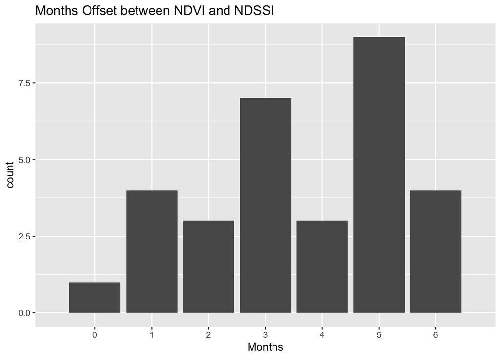

```r
ggplot(DeltaMaxMin, aes(x = MaxOffset)) +
  geom_bar() +
  scale_x_discrete(limits = c(0:6), breaks = c(0:6)) +
  labs(x = "Months") +
  ggtitle("Months Offset between NDVI and NDSSI")
```

Ok, so the idea is that peak NDSSI is more effective if it occurs at moderate NDVI, so let’s look at the NDVI value for the months with peak NDSSI.

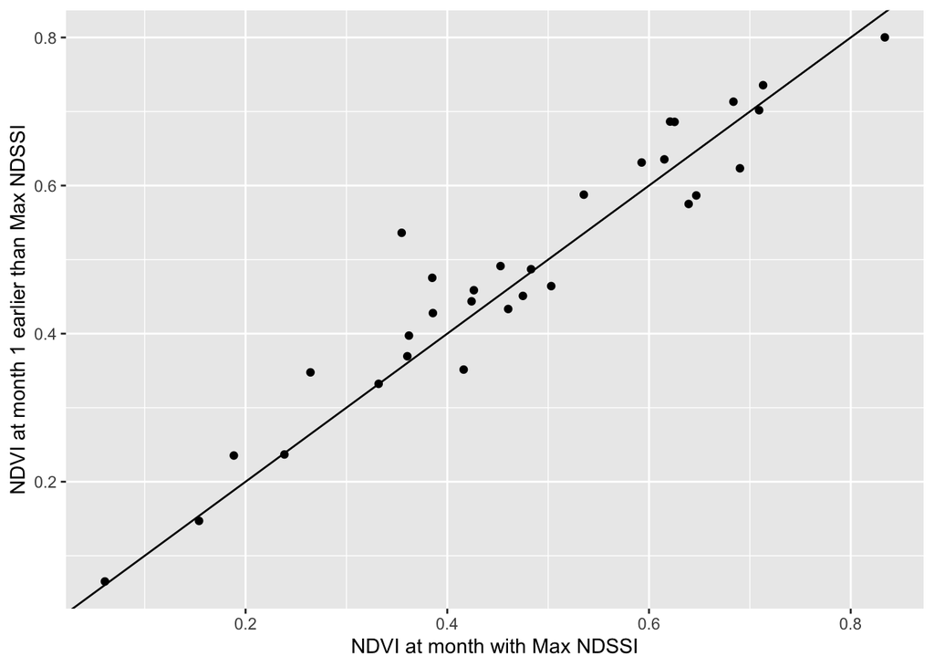

```r
#extract NDVI value for each delta a the month of max NDSSI value

MaxNDSSI <- DeltaMaxMin %>%
  select(Delta,MaxMeanNDSSImonth) %>%
  left_join(filter(DeltaMeans,surface == 'Land'),
            by = c('Delta', 'MaxMeanNDSSImonth' ='month')) %>%
  select (-c(surface, MeanNDSSI)) %>%
  mutate(maxmonthNDVI = MeanNDVI) %>%
  select (-c(MeanNDVI,MaxMeanNDSSImonth))


#extract NDVI value for each delta at one month earlier than max NDSSI value

MaxNDSSIEarly <- DeltaMaxMin %>%
  select(Delta,MaxMeanNDSSImonth) %>%
  mutate(EarlyNDSSI = if_else(MaxMeanNDSSImonth == 1, 12, MaxMeanNDSSImonth-1)) %>%
  select (-c(MaxMeanNDSSImonth)) %>%
  left_join(filter(DeltaMeans,surface == 'Land'),
            by = c('Delta', 'EarlyNDSSI' ='month')) %>%
  select (-c(surface, MeanNDSSI)) %>%
  mutate(EarlyNDVI = MeanNDVI) %>%
  select (-c(MeanNDVI,EarlyNDSSI))

joinedPeakNDSSI <- left_join(MaxNDSSI, MaxNDSSIEarly, by = c('Delta'))

#remove intermediate data
rm(MaxNDSSI, MaxNDSSIEarly)


ggplot(joinedPeakNDSSI, aes(x = maxmonthNDVI, y = EarlyNDVI)) +
  geom_point() + geom_abline(slope=1, intercept=0) + labs(x = "NDVI at month with Max NDSSI", y = "NDVI at month 1 earlier than Max NDSSI")
```

```r
# ggplot(data= joinedPeakNDSSI) +
#   geom_density(aes(x=maxmonthNDVI),fill=1, alpha = 0.6) +
#   geom_density(aes(x=EarlyNDVI),fill=3, alpha = 0.6) +
#   xlim(0,1) +
#   labs(x = "NDVI") +
#   ggtitle("NDVI at month of maximum mean NDSSI and one month before")
```

Just to explore the data a bit, here are offsets against other measured parameters for each delta. The range, max and mean of NDVI and NDSSI is calculated from the timeseries, so it is really the max, min, and range of the monthly means (i.e., the maximum of the means, the minimum of the means, and the range of the mean). Offset is measured in months.

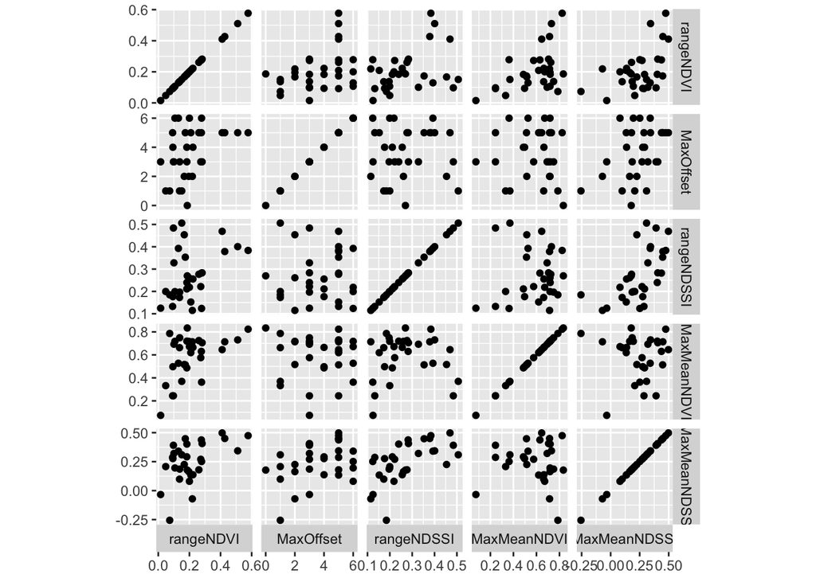

```r
ggplot(data = select(DeltaMaxMin,rangeNDVI,MaxOffset,
                         rangeNDSSI,MaxMeanNDVI,MaxMeanNDSSI)) +
  geom_autopoint(na.rm = TRUE) +
  facet_matrix(rows = vars(rangeNDVI:MaxMeanNDSSI),
               switch = "x") + theme(aspect.ratio=1)
```

Join Latitude and longitude data

```r
DeltaDatawLocations <- left_join(select(DeltaMaxMin,rangeNDVI,MaxOffset,
                         rangeNDSSI,MaxMeanNDVI,MaxMeanNDSSI),
                         DeltaLocations, by = c("Delta" = "Deltas"))
```

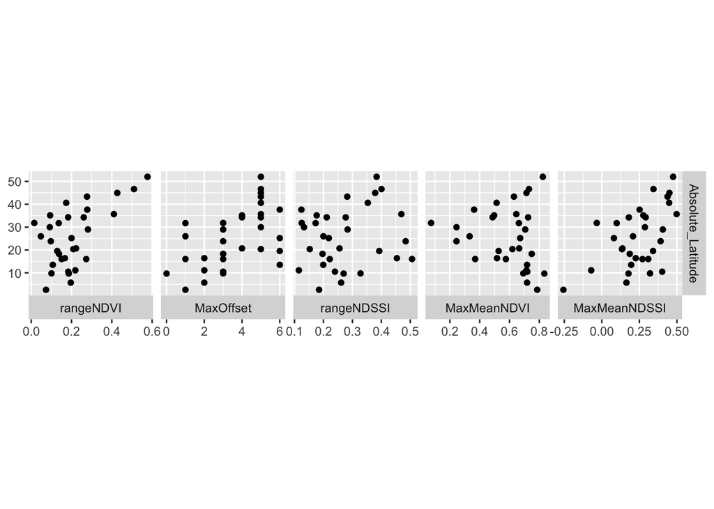

```r
DeltaDatawLocations <- DeltaDatawLocations %>%
  mutate(Absolute_Latitude= abs(Lat))

ggplot(data = DeltaDatawLocations) +
  geom_autopoint(na.rm = TRUE) +
  facet_matrix(cols = vars(rangeNDVI:MaxMeanNDSSI), rows = vars(Absolute_Latitude) ,
               switch = "x") + theme(aspect.ratio=1)
```

So Offset and Lat seem to have a relationship:

```r
#find the linear model
DeltaOffset_lm <- lm( Absolute_Latitude ~ MaxOffset, data = DeltaDatawLocations)

summary(DeltaOffset_lm)
```

```
##
## Call:
## lm(formula = Absolute_Latitude ~ MaxOffset, data = DeltaDatawLocations)
##
## Residuals:
##     Min      1Q  Median      3Q     Max
## -21.779  -8.983   0.775   8.377  20.772
##
## Coefficients:
##             Estimate Std. Error t value Pr(>|t|)
## (Intercept)   10.820      4.629   2.337  0.02653 *
## MaxOffset      4.079      1.157   3.525  0.00143 **
## ---
## Signif. codes:  0 '***' 0.001 '**' 0.01 '*' 0.05 '.' 0.1 ' ' 1
##
## Residual standard error: 11.06 on 29 degrees of freedom
## Multiple R-squared:  0.2999, Adjusted R-squared:  0.2758
## F-statistic: 12.43 on 1 and 29 DF,  p-value: 0.001428
```

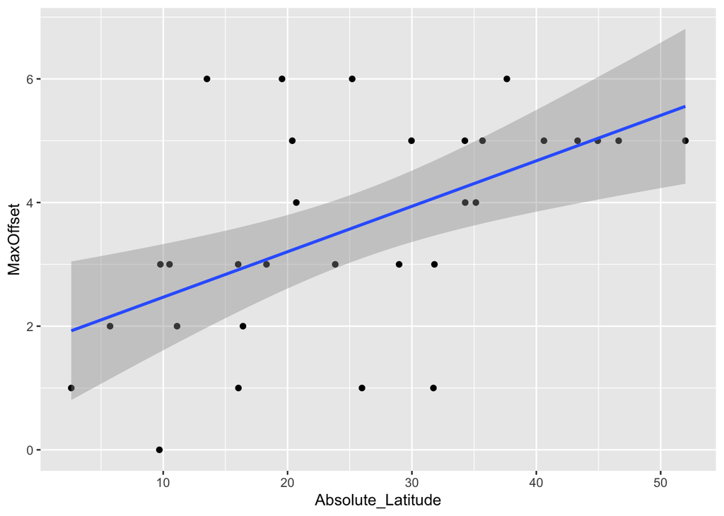

```r
ggplot(DeltaDatawLocations, aes(x = Absolute_Latitude, y = MaxOffset)) +
  geom_point() +
  geom_smooth(mapping = aes(x = Absolute_Latitude, y = MaxOffset, ), method=lm )
```

Now for some maps of the data maps:

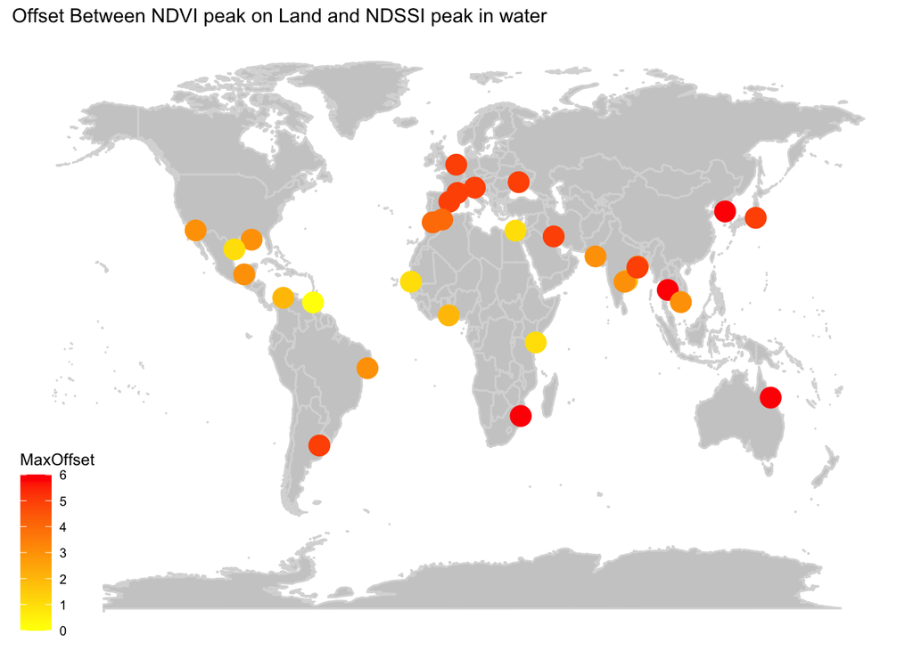

```r
world <- ggplot() +
  borders("world", colour = "gray85", fill = "gray80") +
  theme_map()

DeltaOffsetMap <- world +
  geom_point(aes(x = Lon, y = Lat, color = MaxOffset),
             data = DeltaDatawLocations,
             size = 5) + scale_color_gradient( high = "red", low  = "yellow") +
  ggtitle("Offset Between NDVI peak on Land and NDSSI peak in water")

world <- ggplot() +
  borders("world", colour = "gray85", fill = "gray80") +
  theme_map()

DeltaNDVIrangeMap <- world +
  geom_point(aes(x = Lon, y = Lat, color = rangeNDVI),
             data = DeltaDatawLocations,
             size = 5) + scale_color_gradient( high = "red", low  = "yellow") +
  ggtitle("NDVI range")


DeltaNDSSIrangeMap  <- world +
  geom_point(aes(x = Lon, y = Lat, color = rangeNDSSI),
             data = DeltaDatawLocations,
             size = 5) + scale_color_gradient( high = "red", low = "yellow") + ggtitle("NDSSI range")


DeltaOffsetMap
```

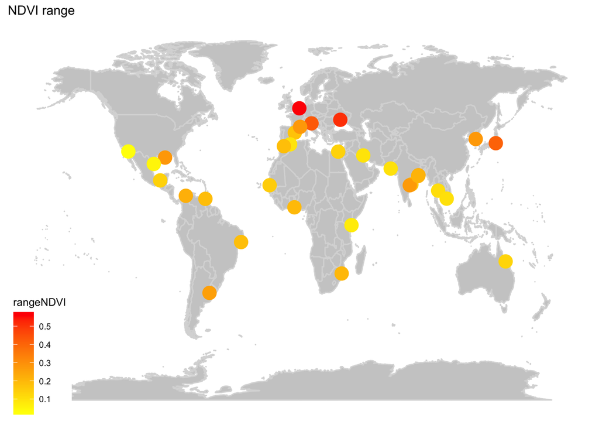

```r
DeltaNDVIrangeMap
```

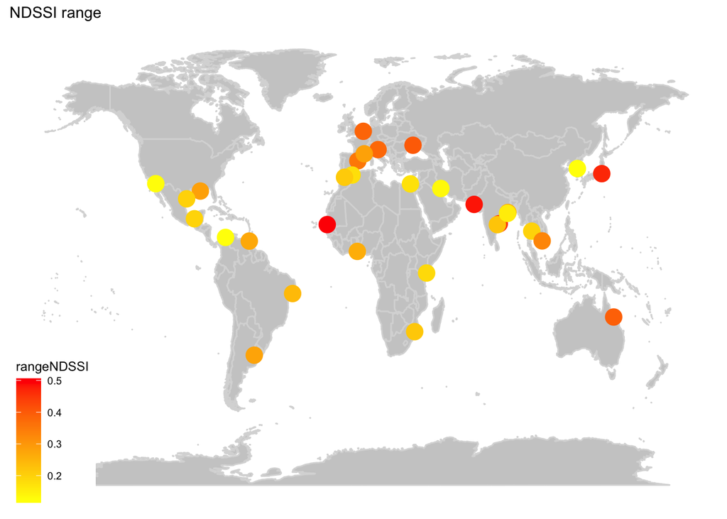

```r
DeltaNDSSIrangeMap
```

```r
#ggsave("DeltaOffsetMap.pdf", width = 6, height = 4)
#ggsave("DeltaNDVIrangeMap.pdf", width = 6, height = 4)
#ggsave("DeltaNDSSIrangeMap.pdf", width = 6, height = 4)
```

Let’s look at some of the timeseries To quantify the water, we use NDSSI. to quantify land, we use NDVI.

First here is the function to make the plots:

```r
DeltaPlotter <- function(DeltaName) {
  #Counts each month
  numVeg <- DeltasCleaner %>%
    select(Delta, surface, month, ndvi) %>%
    filter(Delta == DeltaName & surface == "Land" & !is.na(ndvi)) %>%
    group_by(month) %>%
    summarize(n = n())

  numSed <- DeltasCleaner %>%
    select(Delta, surface, month, ndssi) %>%
    filter(Delta == DeltaName &
             surface == "Water" & !is.na(ndssi)) %>%
    group_by(month) %>%
    summarize(n = n())

  #Highlight the Maximum and Minimum Month for each delta, NDVI and NDSSI

  #LAND
  Veg <-
    ggplot(data = filter(DeltasCleaner, Delta == DeltaName &
                           surface == "Land")) +
    geom_boxplot(aes(x = month, y = ndvi, group = month)) +
    scale_x_discrete(limits = c(1:12), breaks = c(1:12)) +
    expand_limits(x = c(1, 12)) +
    ggtitle(DeltaName) +
    #geom_text(data = numVeg, aes(y = 1.05, x = month, label = n)) +
    geom_boxplot(
      data = filter(
        DeltasCleaner,
        Delta == DeltaName &
          surface == "Land" & month == DeltaMaxMin$MaxMeanNDVImonth[DeltaMaxMin$Delta == DeltaName]
      ),
      aes(x = month, y = ndvi, group = month),
      fill = "green"
    ) +
    geom_boxplot(
      data = filter(
        DeltasCleaner,
        Delta == DeltaName &
          surface == "Land" & month == DeltaMaxMin$MinMeanNDVImonth[DeltaMaxMin$Delta ==DeltaName]
      ),
      aes(x = month, y = ndvi, group = month),
      fill = "blue"
    )


  Sed <-
    ggplot(data = filter(DeltasCleaner, Delta == DeltaName &
                           surface == "Water")) +
    geom_boxplot(aes(x = month, y = ndssi, group = month)) +
    scale_x_discrete(limits = c(1:12), breaks = c(1:12)) +
    expand_limits(x = c(1, 12)) +
    #geom_text(data = numSed, aes(y = 1.05, x = month, label = n)) +
    geom_boxplot(
      data = filter(
        DeltasCleaner,
        Delta == DeltaName &
          surface == "Water" & month == DeltaMaxMin$MaxMeanNDSSImonth[DeltaMaxMin$Delta == DeltaName]
      ),
      aes(x = month, y = ndssi, group = month),
      fill = "green"
    ) +
    geom_boxplot(
      data = filter(
        DeltasCleaner,
        Delta == DeltaName &
          surface == "Water" & month == DeltaMaxMin$MinMeanNDSSImonth[DeltaMaxMin$Delta == DeltaName]
      ),
      aes(x = month, y = ndssi, group = month),
      fill = "blue"
    )

  return(grid.arrange(Veg, Sed, nrow = 2))
}
```

Here is are some examples:

- The peaks in both timeseries shift around depending on the delta:
  - look at the correlation in the Orinoco nad Senegal
  - The anticorrelation in the Parana and Ebro,
  - The slight phase shift in the Magdalena.

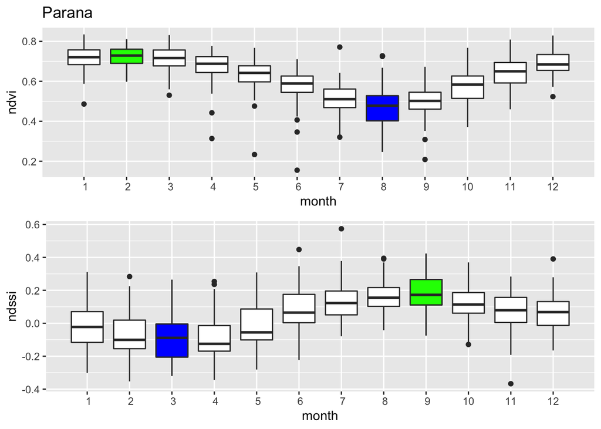

```r
DeltaPlotter("Parana")
```

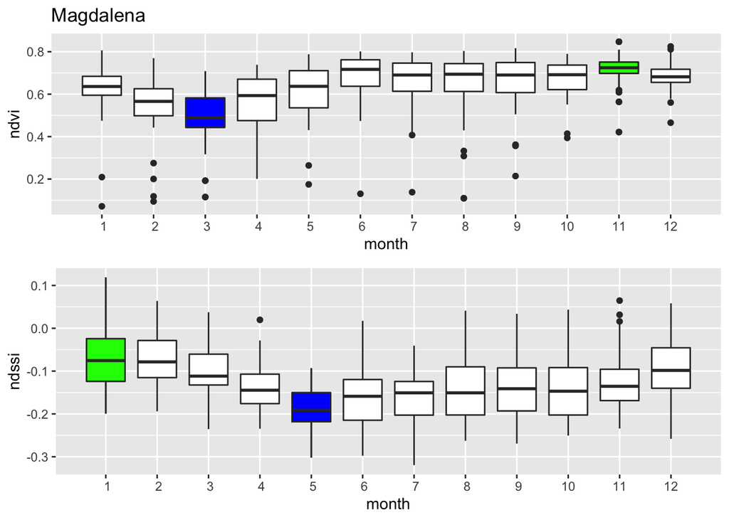

```r
DeltaPlotter("Magdalena")
```

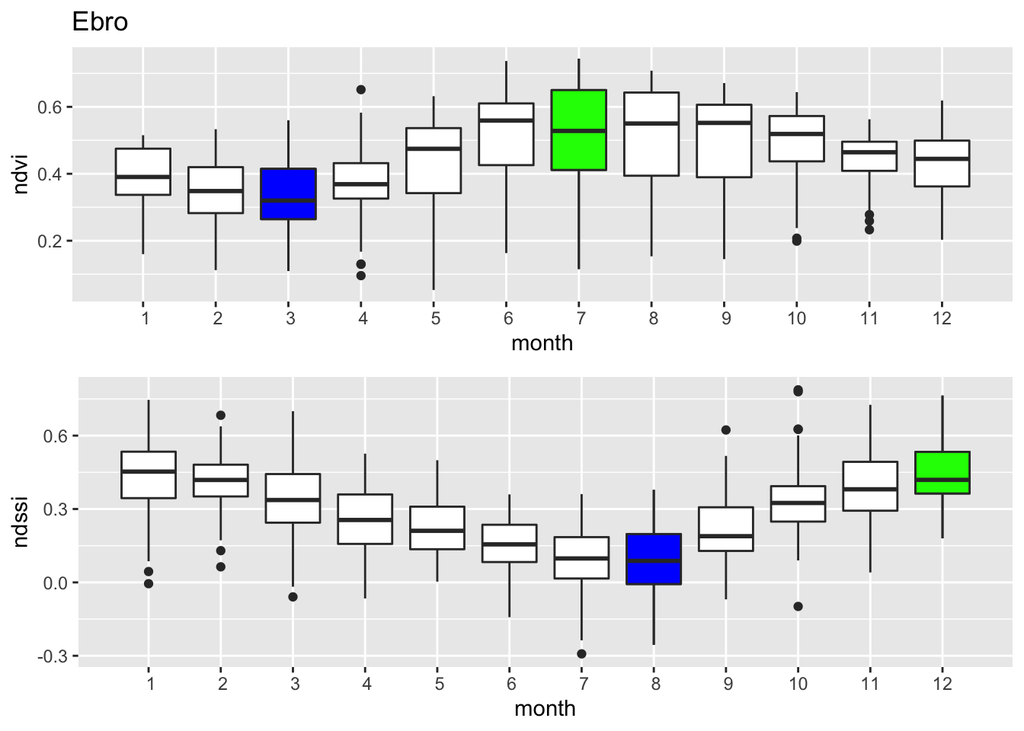

```r
DeltaPlotter("Ebro")
```

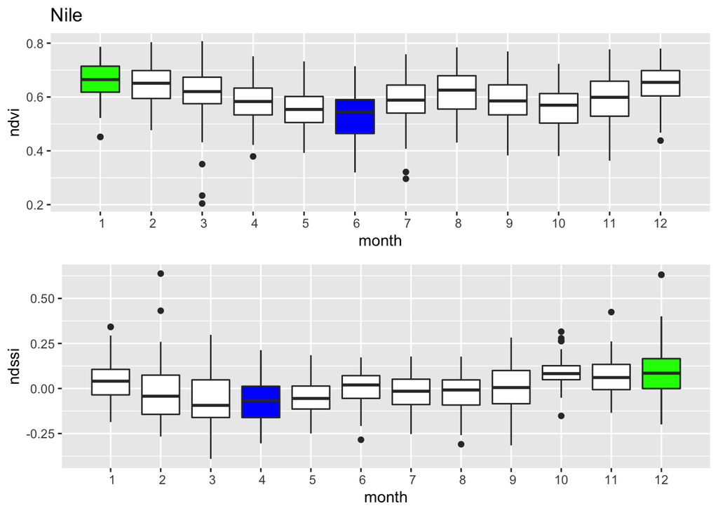

```r
DeltaPlotter("Nile")
```

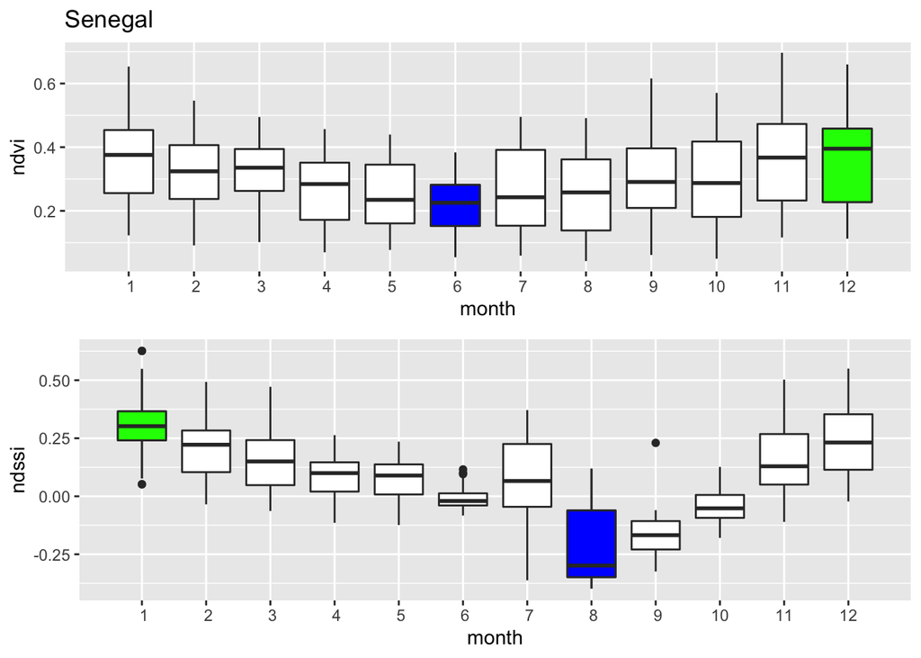

```r
DeltaPlotter("Senegal")
```

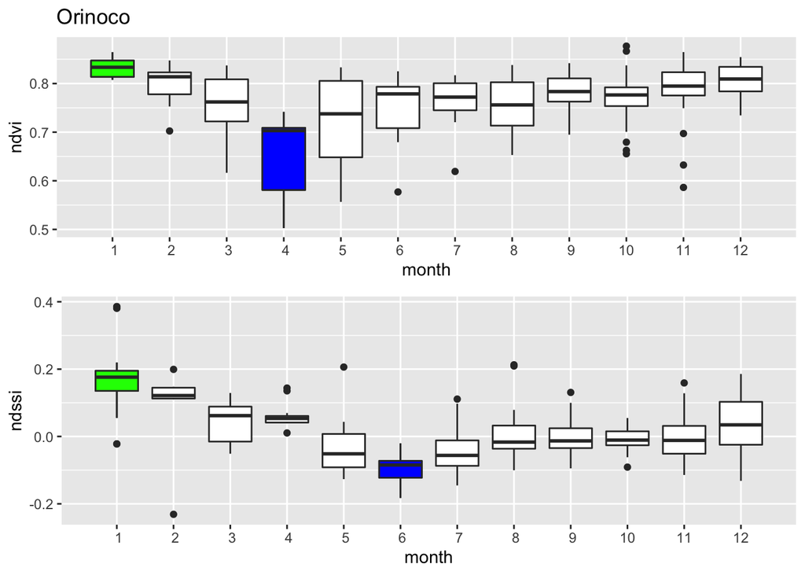

```r
DeltaPlotter("Orinoco")
```

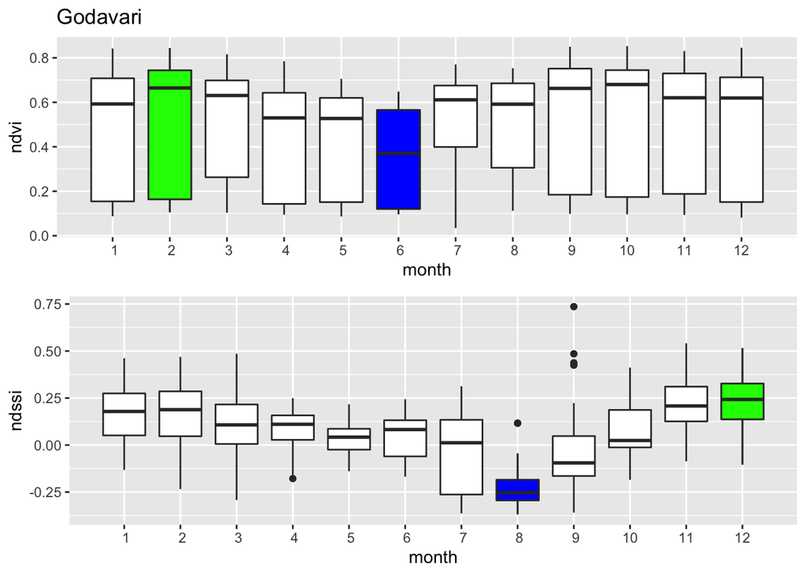

```r
DeltaPlotter("Godavari")
```

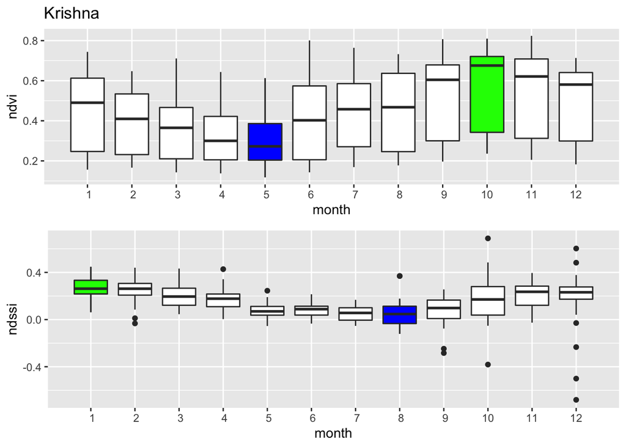

```r
DeltaPlotter("Krishna")
```

And Finally, we can look at GRDC data:

```r
#import the data (monthly means for 21 stations)
DeltasGRDC  <- read_csv("../data/GRDCstations.csv")
```

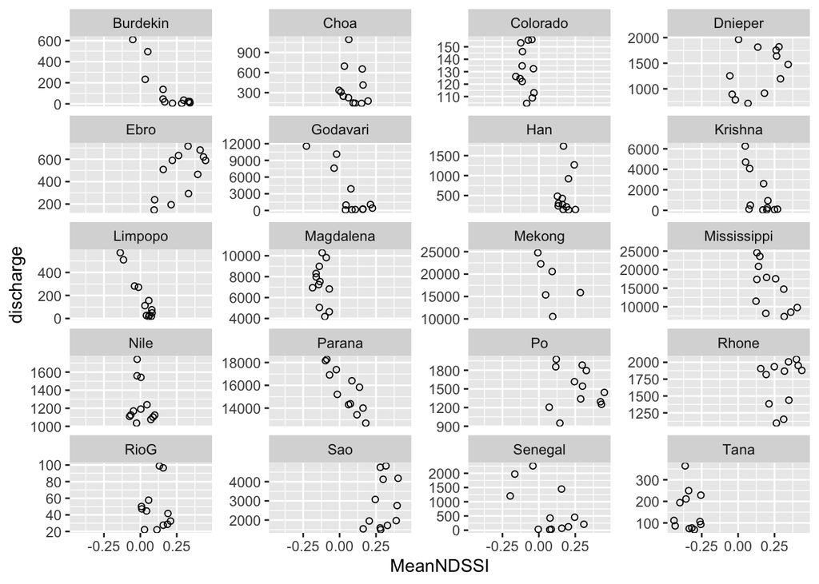

```r
#calculate the mean of the monthly means
DeltasGRDC <- DeltasGRDC %>%
    rowwise() %>%
    mutate(MMD=mean(c(January,February,March,April,
                    May,June,July,August,
                    September,October,November,December)))  %>%
  rowwise() %>%
  mutate(Range_Discharge = max(c(January,February,March,April,
              May,June,July,August,
              September,October,November,December)) -
           min(c(January,February,March,April,
              May,June,July,August,
              September,October,November,December))
           ) %>%
  right_join(DeltaDatawLocations, by = c("Deltas" = "Delta"))

#rename the months by numbers and tidy the GRDC data
DeltasDischarge <- DeltasGRDC %>%
  rename(Delta = Deltas,"1" = January, "2"= February, "3"= March, "4"= April,
         "5"=May, "6"=June, "7"=July, "8"= August, "9" = September, "10"=October,
         "11"=November, "12"=December) %>%
  select(Delta, "1" , "2" , "3", "4","5", "6", "7", "8", "9", "10", "11", "12") %>%
  pivot_longer(-Delta, names_to = "month", values_to = "discharge")

DeltasDischarge$month = as.numeric(DeltasDischarge$month)

DisNDSSI <- DeltaMeans %>%
  filter(surface == 'Water')  %>%
  select (-c(MeanNDVI)) %>%
  left_join(DeltasDischarge, by = c('Delta', 'month')) %>%
  drop_na(discharge)

#plot monthly means against NDSSI for deltas with GRDC discharge data
ggplot(DisNDSSI, aes(y=discharge, x=MeanNDSSI)) + geom_point(shape=1) + facet_wrap( ~ Delta, ncol=4, , scales="free_y")
```